# Wpływ Social Media na życia studentów

# 1 Wprowadzenie

W dobie powszechnej cyfryzacji media społecznościowe stały się nieodłącznym elementem codzienności akademickiej, kształtując sposób, w jaki studenci komunikują się, spędzają wolny czas i budują relacje. Celem niniejszego raportu jest wielowymiarowa analiza wpływu korzystania z platform społecznościowych na dobrostan studentów. Szczególny nacisk położono na zbadanie korelacji między czasem ekranowym a zdrowiem psychicznym, jakością snu oraz wynikami w nauce.

Raport zawiera przegląd kluczowych statystyk, wizualizację rozkładu zmiennych oraz wnioski płynące z analizy zależności między cechami demograficznymi a wzorcami zachowań cyfrowych. Analizowany zbiór danych składa się z 705 obserwacji oraz 13 zmiennych, obejmujących m.in. dane demograficzne, preferowane platformy, czas użytkowania oraz wskaźniki subiektywnego poczucia uzależnienia.

Projekt pomoże poznać czy istnieje statystycznie istotny wpływ ilości snu, średniego czasu spędzanego przed telefonem oraz oceny uzależnienia na wyniki akademickie. Ponadto, dowiemy się czy istnieje zależność między poziomem edukacji a najczęściej używaną aplikacją oraz czy istnieje zależność między średnim czasem używania social mediów a liczbą konfliktów na tle korzystania z mediów społecznościowych.

## 1.1 Opis danych

Analizowany zbiór danych składa się z 13 zmiennych dotyczących studentów z różnych krajów. Dane obejmują trzy kluczowe obszary:

- Demografię (m.in. wiek, płeć, poziom edukacji).
- Aktywność w sieci (średni czas korzystania, najczęściej używana platforma).
- Wskaźniki dobrostanu (poziom uzależnienia, ocena zdrowia psychicznego, jakość snu oraz wpływ na wyniki w nauce).

Zbiór jest kompletny i nie zawiera brakujących wartości.

# 2 Porządkowanie danych

## 2.1 Braki danych

W danych znajduje się 100 % kompletnych wartości.

## 2.2 Walidacja danych

- czy wiek przyjmuje wartości od 16 - 25?
- czy średni czas użycia przyjmuje wartości 0 - 24?
- czy wszystkie wartości liczbowe są większe od 0?
- czy mental health score i addicted score przyjmują wartości 1 - 10?
- płeć - kobieta lub mężczyzna?
- poziom wykształcenia - szkoła średnia, studia I stopnia lub studia II stopnia
- status związku - wolny, w związku, “to skomplikowane”
- czy wpływa na wyniki akademickie - tak lub nie?

```r
reguly <- validator(
Wiek = Age >= 16 & Age <= 25,
Płeć = Gender %in% c("Female", "Male"),
Poziom_Edukacji = Academic_Level  %in% c("High School", "Undergraduate", "Graduate"),
Średni_Czas_Użycia = Avg_Daily_Usage_Hours > 0 & Avg_Daily_Usage_Hours < 24,
Wpływ_na_Nauke = Affects_Academic_Performance %in% c("Yes", "No"),
Sen = Sleep_Hours_Per_Night >= 0 & Sleep_Hours_Per_Night <= 24,
Zdrowie_psychiczne = Mental_Health_Score >= 1 & Mental_Health_Score<=10,
Status_związkowy = Relationship_Status %in% c("In Relationship", "Single", "Complicated"),
Wynik_uzależnienia = Addicted_Score >= 1 & Addicted_Score <= 10
)
```

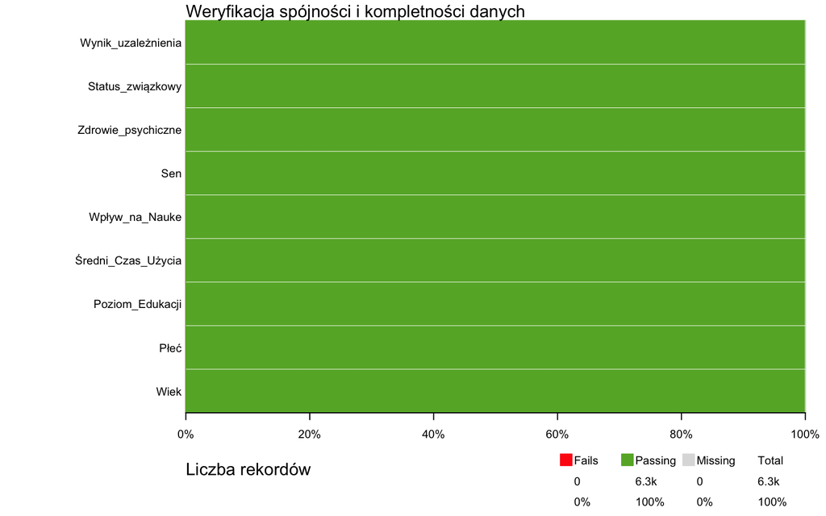

```r
cf <- confront(dane, reguly, key="Student_ID")

par(mar = c(5, 10, 4, 2))

plot(cf,
      title = "Weryfikacja spójności i kompletności danych",
     xlab = "Liczba rekordów",
     las = 1,                              # Etykiety poziomo
     cex.axis = 0.8,                       # Czcionka osi
)
```

# 3 Wizualizacja danych

## 3.1 Charakterystyka demograficzna badanej grupy studenckiej

### 3.1.1 Rozkład Płci i Poziomu Akademickiego

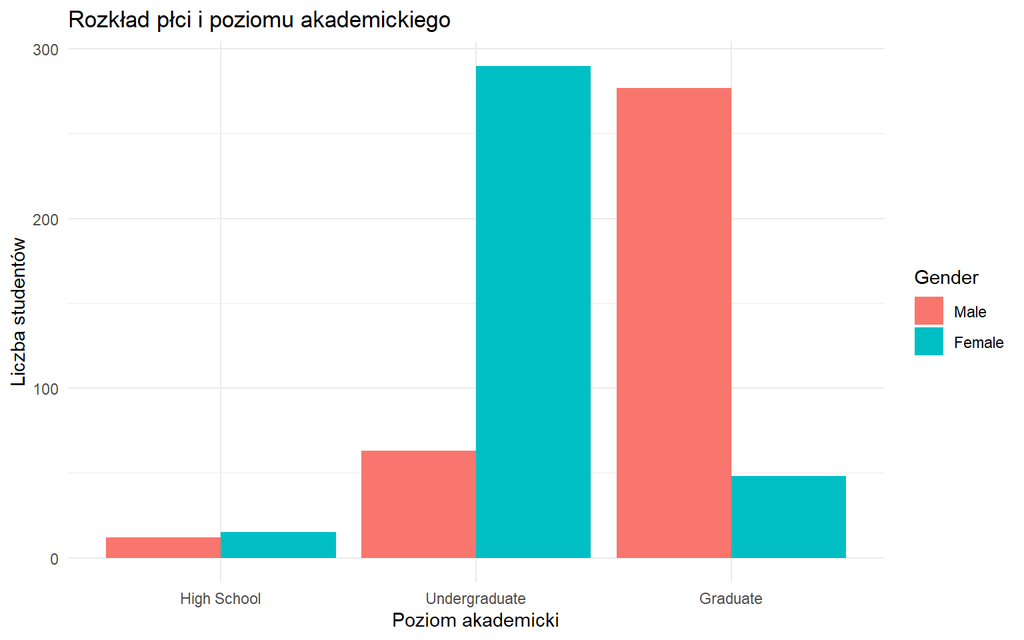

```r
dane$Academic_Level <- factor(dane$Academic_Level,
                            levels = c("High School", "Undergraduate", "Graduate"))
dane$Gender <- factor(dane$Gender,
                  levels = c("Male", "Female")
)

ggplot(dane, aes(x = Academic_Level, fill=Gender)) +
  geom_bar(position = "dodge") +
  labs(title = "Rozkład płci i poziomu akademickiego",
       x = "Poziom akademicki",
       y = "Liczba studentów") +
  theme_minimal()
```

Analiza struktury demograficznej wskazuje na równomierny rozkład płci (blisko 50/50), natomiast w podziale na poziom edukacji przeważają osoby na studiach I i II stopnia, stanowiąc łącznie ponad 96% próby.

### 3.1.2 Wiek badanych

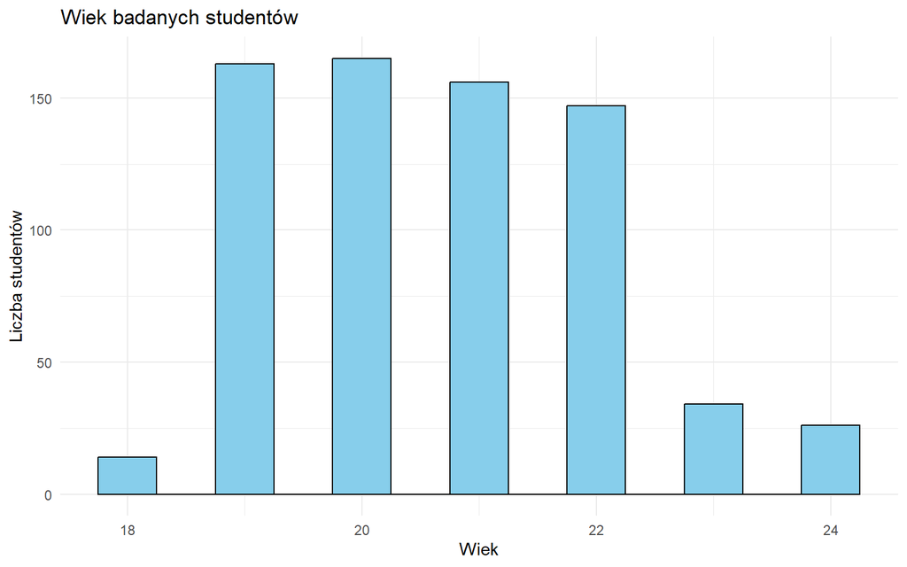

```r
ggplot(dane, aes(x = Age)) +
  geom_histogram(binwidth = 0.5, fill = "skyblue", color = "black") +
  labs(title = "Wiek badanych studentów",
       x = "Wiek",
       y = "Liczba studentów") +
  theme_minimal()
```

Większość badanych to osoby w wieku od 19 do 23 lat, co wskazuje na silną koncentrację danych wokół typowego wieku studenckiego. Średnia wieku w próbie wynosi około 21 lat.

## 3.2 Intensywność Używania Social Mediów

### 3.2.1 Średni czas używania Social Mediów

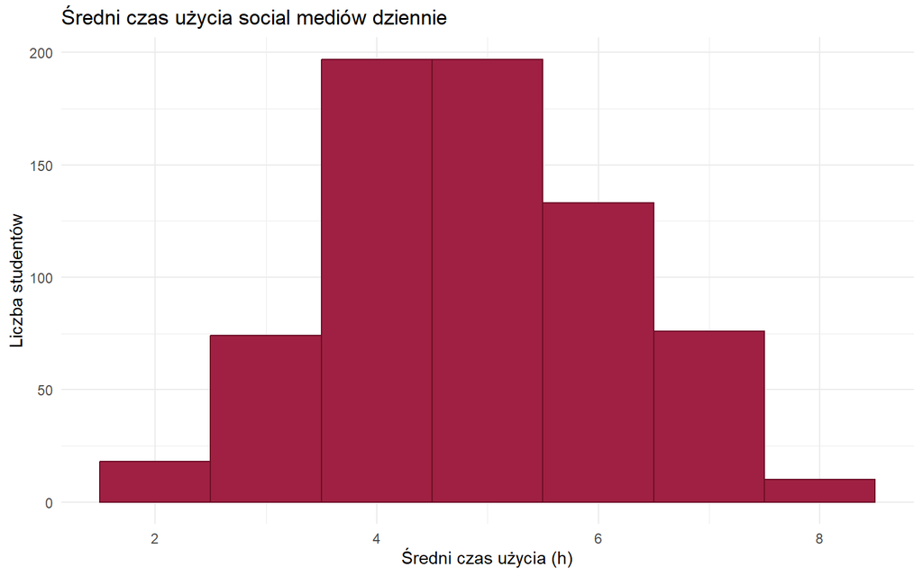

```r
ggplot(dane, aes(x = Avg_Daily_Usage_Hours)) +
  geom_histogram(binwidth = 1, fill = "#9f2042", color = "#6c0d27") +
  labs(title = "Średni czas użycia social mediów dziennie",
       x = "Średni czas użycia (h)",
       y = "Liczba studentów") +
  theme_minimal()
```

Większość studentów spędza w mediach społecznościowych od 4 do 6 godzin dziennie, przy czym średnia dla całej grupy wynosi blisko 5 godzin. Rozkład wskazuje, że znaczna część badanych deklaruje wysoką aktywność cyfrową, przekraczającą 4 godziny na dobę.

### 3.2.2 Najczęściej używane platformy

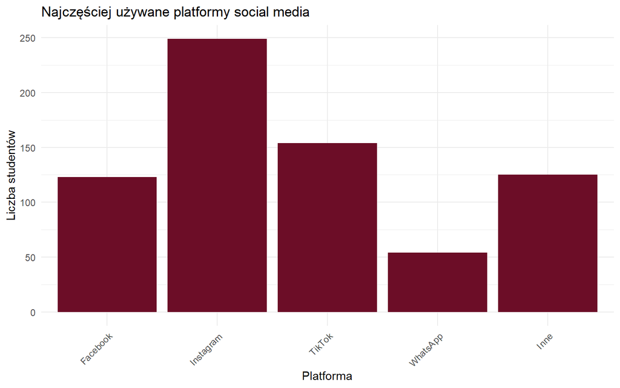

```r
dane %>%
mutate(top_5 = fct_lump_n(Most_Used_Platform, n = 4, other_level = "Inne")) %>%
  ggplot(aes(x = top_5)) +
  geom_bar(fill = "#6c0d27") +
  labs(title = "Najczęściej używane platformy social media",
       x = "Platforma",
       y = "Liczba studentów") +
  theme_minimal() +
  theme(axis.text.x = element_text(angle = 45, hjust = 1))
```

Większość badanych studentów najczęściej korzysta z Instagrama, który z wynikiem blisko 250 wskazań dominuje nad pozostałymi platformami. Znaczną popularnością cieszy się również TikTok, a podium zamyka Facebook, który osiągnął podobny wynik do sumy zebranej przez resztę aplikacji nie pokazanych na wykresie (m.in. Snapchat, Twitter czy LinkedIn).

## 3.3 Charakterystyka wpływu mediów społecznościowych

### 3.3.1 Poziom uzależnienia od Social Mediów

```r
wykres <- dane %>%
  count(Addicted_Score) %>%
  ggplot(aes( x = Addicted_Score, y=n)) +
  geom_point(color= "blue")+
  geom_line(color= "blue")+
  labs(title = "Poziom uzależnienia uczniów",
       x = "Poziom uzależnienia",
       y = "Liczba uczniów") +
  theme_minimal() +
  theme(
    plot.title = element_text(hjust = 0.5)
  )
plotly:: ggplotly(wykres)
```

[interactive chart not shown]

Największa liczba badanych koncentruje się na umiarkowanych i wyższych poziomach uzależnienia, co wskazuje na powszechność intensywnego korzystania z mediów społecznościowych w badanej grupie.

### 3.3.2 Wpływ Social Mediów na wyniki akademickie

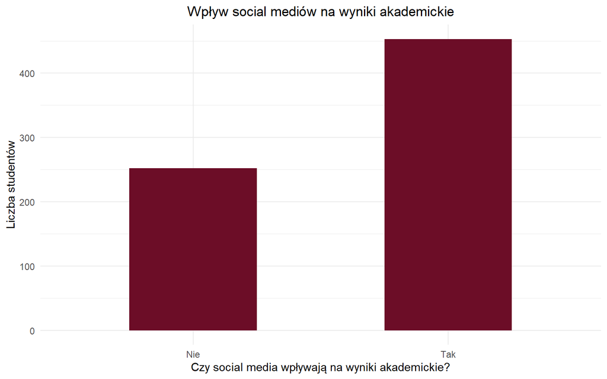

```r
ggplot(dane, aes(x = Affects_Academic_Performance)) +
  geom_bar(fill = "#6c0d27", width= 0.5)+
  scale_x_discrete(
    labels = c(
      "Yes" = "Tak",
      "No"  = "Nie"
    )
  ) +
  labs(title = "Wpływ social mediów na wyniki akademickie",
       x = "Czy social media wpływają na wyniki akademickie?",
       y = "Liczba studentów")+
         theme_minimal()+
   theme(
    plot.title = element_text(hjust = 0.5)
  )
```

Zdecydowana większość badanych zadeklarowała, że korzystanie z social mediów wpływa na ich osiągnięcia akademickie, podczas gdy mniejsza część respondentów nie dostrzega takiego wpływu. Uzyskane wyniki sugerują, że studenci w dużym stopniu są świadomi oddziaływania mediów społecznościowych na wyniki w nauce.

## 3.4 Zdrowie psychiczne studentów

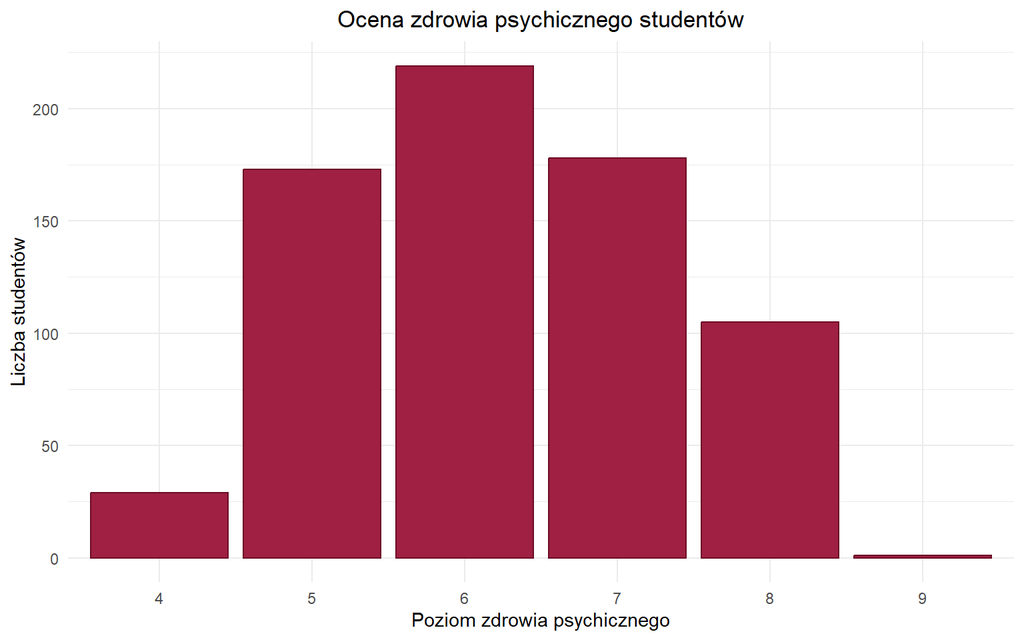

```r
#mozaikowy, na plakacie z ggplota
ggplot(dane, aes(x = factor(Mental_Health_Score, levels = 1:10))) +
  geom_bar(fill = "#9f2042", color = "#6c0d27")+
  labs(
    title = "Ocena zdrowia psychicznego studentów",
    x = "Poziom zdrowia psychicznego",
    y = "Liczba studentów"
  ) +
  theme_minimal() +
  theme(plot.title = element_text(hjust = 0.5))
```

Rozkład ocen zdrowia psychicznego studentów wskazuje, że odpowiedzi koncentrują się w środkowym zakresie skali. Najczęściej deklarowane wartości mieszczą się pomiędzy 5 a 7 punktów, przy czym najwyższą liczebność odnotowano dla oceny 6. W badanej próbie nie odnotowano odpowiedzi dla najniższych wartości skali (1–3) ani dla wartości maksymalnej (10), co sugeruje brak skrajnie negatywnych oraz skrajnie pozytywnych ocen zdrowia psychicznego wśród respondentów. Uzyskany rozkład wskazuje na umiarkowany poziom subiektywnego dobrostanu psychicznego w analizowanej grupie studentów.

# 4 Statystyki opisowe

## 4.1 Statystyki opisowe średniego dziennego czasu korzystania z mediów społecznościowych w podziale na 5 najczęściej używanych platform

Ze względu na nierówną liczebność obserwacji w poszczególnych kategoriach zmiennej Most Used Platform, analizę ograniczono do pięciu najczęściej deklarowanych platform społecznościowych.

```r
top5_platform <- dane %>%
  count(Most_Used_Platform, sort = TRUE) %>%
  slice_head(n = 5) %>%
  pull(Most_Used_Platform)

Avg_Daily_Usage_Hours <- dane %>%
  filter(Most_Used_Platform %in% top5_platform) %>%
  group_by(Most_Used_Platform) %>%
  summarise(
    N = n(),
    Min = min(Avg_Daily_Usage_Hours),
    Q1 = quantile(Avg_Daily_Usage_Hours, 0.25),
    Mediana = median(Avg_Daily_Usage_Hours),
    Średnia = mean(Avg_Daily_Usage_Hours),
    Q3 = quantile(Avg_Daily_Usage_Hours, 0.75),
    Max = max(Avg_Daily_Usage_Hours),
    SD = sd(Avg_Daily_Usage_Hours),
    IQR = IQR(Avg_Daily_Usage_Hours)
  )

kable(
  Avg_Daily_Usage_Hours,
  digits = 2,
  caption = "Statystyki opisowe Avg_Daily_Usage_Hours dla 5 najczęściej używanych platform"
) %>%
  kable_paper(full_width = FALSE)
```

Statystyki opisowe Avg_Daily_Usage_Hours dla 5 najczęściej używanych platform

| Most_Used_Platform | N | Min | Q1 | Mediana | Średnia | Q3 | Max | SD | IQR |
| --- | --- | --- | --- | --- | --- | --- | --- | --- | --- |
| Facebook | 123 | 2.3 | 3.7 | 4.50 | 4.51 | 5.00 | 7.2 | 1.11 | 1.30 |
| Instagram | 249 | 2.2 | 4.0 | 4.70 | 4.87 | 5.70 | 8.5 | 1.24 | 1.70 |
| TikTok | 154 | 3.3 | 4.6 | 5.30 | 5.35 | 5.97 | 8.4 | 1.05 | 1.38 |
| Twitter | 30 | 2.1 | 4.4 | 4.65 | 4.87 | 5.47 | 6.3 | 0.87 | 1.07 |
| WhatsApp | 54 | 5.5 | 6.0 | 6.45 | 6.48 | 7.00 | 7.5 | 0.59 | 1.00 |

Osoby, które wskazały WhatsApp jako najczęściej używaną aplikację, spędzają przeciętnie najwięcej czasu ogółem w mediach społecznościowych w ciągu dnia. Wysoki łączny czas korzystania obserwuje się również wśród użytkowników TikToka, natomiast osoby deklarujące Facebook, Instagram lub Twitter jako najczęściej używaną platformę spędzają w mediach społecznościowych średnio mniej czasu. Największe zróżnicowanie dziennego czasu korzystania występuje wśród użytkowników Instagrama, a najmniejsze w grupie użytkowników WhatsAppa.

Tabela 4.2. Tabela rozkładu poziomu uzależnienia w podziale na TOP 5 najczęściej używanych platform

platform

boxplot

histogram

points1

Facebook

[figure not shown]

Instagram

[figure not shown]

TikTok

[figure not shown]

Twitter

[figure not shown]

WhatsApp

[figure not shown]

## 4.2 Statystyki opisowe poziomu uzależnienia od mediów społecznościowych

```r
raport <- list("Addicted Score" =
                 list("Min"= ~ min(Addicted_Score),
                      "Max"= ~ max(Addicted_Score),
                      "Q1"= ~ quantile(Addicted_Score,0.25),
                      "Mediana"= ~ round(median(Addicted_Score),2),
                      "Q3"= ~ quantile(Addicted_Score,0.75),
                      "Średnia"= ~ round(mean(Addicted_Score),2),
                      "Odch. std."= ~ round(sd(Addicted_Score),2),
                      "IQR"= ~ round(IQR(Addicted_Score),2),
                      "Odch. ćwiartkowe"=~round(IQR(Addicted_Score)/2,2),
                      "Odch. std. w %"=~round((sd(Addicted_Score)/mean(Addicted_Score)),2), "Odch. ćwiartkowe w %"=~round((IQR(Addicted_Score)/median(Addicted_Score)),2), "Skośność"=~round(skew(Addicted_Score),2), "Kurtoza"=~round(kurtosi(Addicted_Score),2) ))
tabela_gender <- dane %>%
  group_by(Gender) %>%
  summarise(
    Min = min(Addicted_Score),
    Q1 = quantile(Addicted_Score, 0.25),
    Mediana = median(Addicted_Score),
    Q3 = quantile(Addicted_Score, 0.75),
    Max = max(Addicted_Score),
    Średnia = mean(Addicted_Score),
    SD = sd(Addicted_Score),
    Skośność = psych::skew(Addicted_Score),
    Kurtoza = psych::kurtosi(Addicted_Score)
  )

kable(tabela_gender,
      digits = 2,
      caption = "Tabela 4.3. Statystyki opisowe Addicted_Score w podziale na płeć") %>%
  kable_paper("striped", full_width = FALSE)
```

Tabela 4.3. Statystyki opisowe Addicted_Score w podziale na płeć

| Gender | Min | Q1 | Mediana | Q3 | Max | Średnia | SD | Skośność | Kurtoza |
| --- | --- | --- | --- | --- | --- | --- | --- | --- | --- |
| Male | 2 | 5 | 7 | 7 | 9 | 6.36 | 1.45 | -0.45 | -0.82 |
| Female | 3 | 5 | 7 | 8 | 9 | 6.52 | 1.71 | -0.24 | -1.05 |

Średnie i mediany wyników uzależnienia są podobne dla obu płci, przy czym kobiety mają nieco wyższą średnią i większą zmienność. Różnice między mężczyznami a kobietami są niewielkie i nie wskazują na znaczącą przewagę jednej grupy pod względem poziomu uzależnienia.

## 4.3 Macierz korelacji między poziomem uzależnienienia od social mediów, zdrowiem psychicznym, wiekiem i średnim czasem używania social mediów

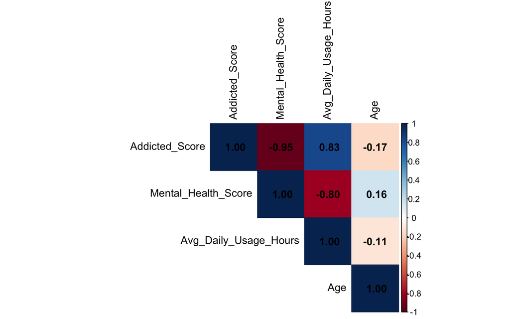

# 5 Wnioskowanie statystyczne

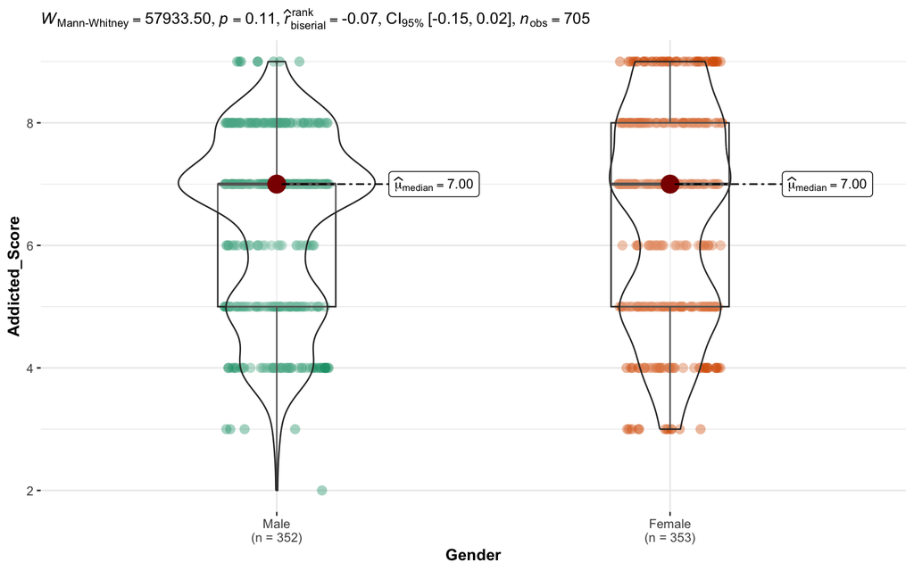

```r
ggbetweenstats(dane, Gender, Addicted_Score,type=("np"))
```

Nie stwierdzono istotnych statystycznie różnic w poziomie uzależnienia od mediów społecznościowych pomiędzy kobietami i mężczyznami (p = 0,11). Mediany wyników w obu grupach są takie same i wynoszą 7, a rozkłady wartości w dużym stopniu się pokrywają. Wielkość efektu jest bardzo mała, co wskazuje, że płeć nie stanowi istotnego czynnika różnicującego poziom uzależnienia w badanej próbie.

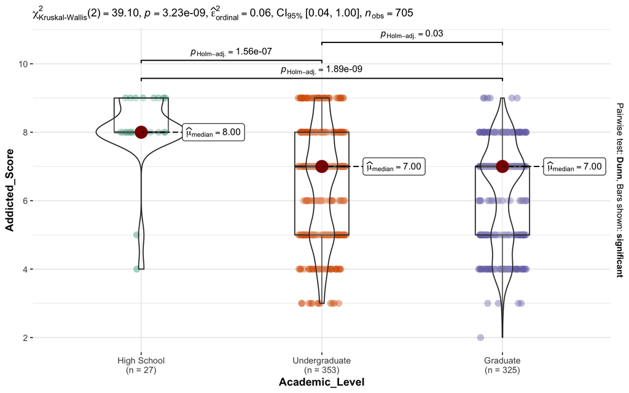

```r
ggbetweenstats(dane, Academic_Level , Addicted_Score,type = "np")
```

```r
anova <- aov(Mental_Health_Score ~ Most_Used_Platform, data=dane)

dane |>
aov(Mental_Health_Score ~ Most_Used_Platform, data=_) |>
tidy() |>
kbl() |>
kable_classic(full_width = FALSE, html_font="Cambria")
```

| term | df | sumsq | meansq | statistic | p.value |
| --- | --- | --- | --- | --- | --- |
| Most_Used_Platform | 11 | 229.1215 | 20.8292240 | 22.89156 | 0 |
| Residuals | 693 | 630.5665 | 0.9099083 | NA | NA |

Wyniki analizy wskazują na istotne statystycznie różnice w ocenie zdrowia psychicznego studentów w zależności od najczęściej używanej platformy społecznościowej. Oznacza to, że średni poziom zdrowia psychicznego nie jest taki sam wśród użytkowników różnych aplikacji.

## 5.1 Czy istnieje zależność między poziomem edukacji a najczęściej używaną aplikacją?

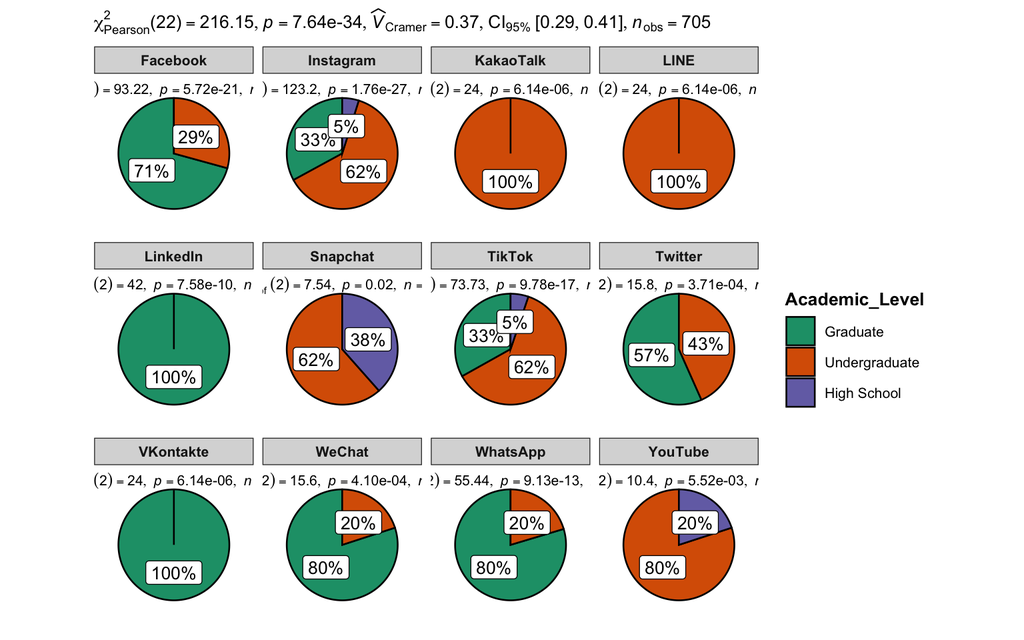

```r
ggpiestats(dane, Academic_Level, Most_Used_Platform, bf.message = FALSE)
```

Analiza wykazała istotną statystycznie zależność między poziomem edukacji a najczęściej używaną platformą społecznościową. Oznacza to, że wybór najczęściej używanej aplikacji różni się w zależności od poziomu edukacji badanych. Umiarkowana wartość współczynnika V Craméra (0,37) wskazuje, że zależność ta jest wyraźna, choć nie ma charakteru silnego. Analiza struktury użytkowników poszczególnych platform wskazuje, że LinkedIn i VKontakte są zdominowane przez osoby na studiach II stopnia, natomiast LINE i KakaoTalk przez studentów studiów I stopnia.

## 5.2 Czy istnieje zależność między średnim czasem używania social mediów a liczbą konfliktów?

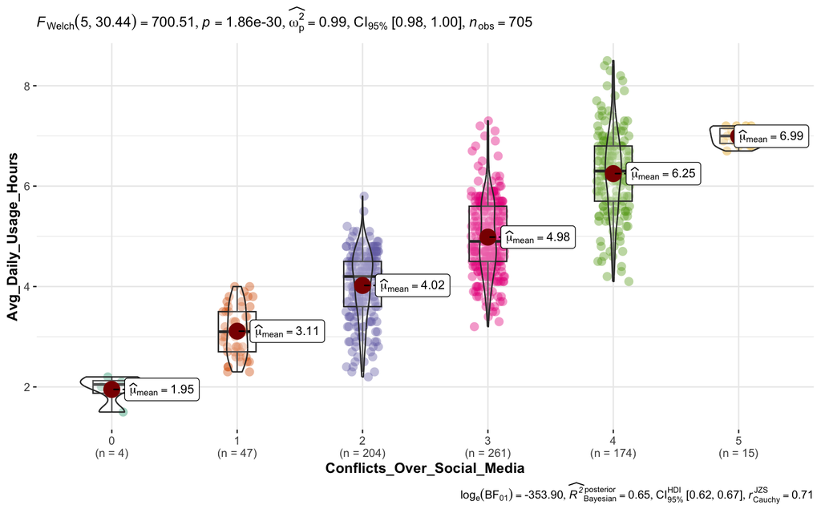

```r
ggbetweenstats(data = dane, x = Conflicts_Over_Social_Media, y =    Avg_Daily_Usage_Hours, pairwise.display = "none")
```

## 5.3 Analiza ANOVA wieloczynnikowa - wpływ snu, czasu korzystania z telefonu i poziomu uzależnienia na wyniki akademickie

```r
dane %>%
  mutate(
    # Konwersja zmiennej wynikowej
    Affects_Academic_Performance = ifelse(Affects_Academic_Performance == "Yes", 1, 0),
    # Upewnienie się, że predyktory są liczbami
    Sleep_Hours_Per_Night = as.numeric(Sleep_Hours_Per_Night),
    Avg_Daily_Usage_Hours = as.numeric(Avg_Daily_Usage_Hours)
  ) %>%
  anova_test(Affects_Academic_Performance ~ Sleep_Hours_Per_Night * Avg_Daily_Usage_Hours * Addicted_Score) %>%
  kbl(digits = 100) %>%
  kable_styling(bootstrap_options = c("striped", "hover"), full_width = F)
```

Effect

DFn

DFd

F

p

p<.05

ges

Sleep_Hours_Per_Night

1

697

0.078

7.80e-01

0.000112

Avg_Daily_Usage_Hours

1

697

18.034

2.46e-05

0.025000

Addicted_Score

1

697

1102.360

0.00e+00

0.613000

Sleep_Hours_Per_Night:Avg_Daily_Usage_Hours

1

697

28.293

1.41e-07

0.039000

Sleep_Hours_Per_Night:Addicted_Score

1

697

56.924

1.42e-13

0.076000

Avg_Daily_Usage_Hours:Addicted_Score

1

697

7.721

6.00e-03

0.011000

Sleep_Hours_Per_Night:Avg_Daily_Usage_Hours:Addicted_Score

1

697

121.026

4.56e-26

0.148000

Wyniki przeprowadzonej analizy ANOVA wskazują na złożone relacje między higieną cyfrową a sukcesem edukacyjnym. Najważniejszym wnioskiem jest dominująca rola zmiennej Addicted_Score, która jako jedyny główny czynnik wykazuje bardzo silny, bezpośredni wpływ na wyniki akademickie (ges=0.613). Co ciekawe, sama liczba godzin snu okazała się nieistotna statystycznie (p=0.78), co sugeruje, że długość wypoczynku nie determinuje ocen w izolacji od pozostałych zachowań. Jednakże klucz do pełnego zrozumienia zjawiska leży w istotnej interakcji trójstopniowej (p<.001,ges=0.148). Oznacza ona, że wpływ snu na wyniki akademickie jest ściśle uzależniony od tego, jak intensywnie badany korzysta z telefonu oraz jaki jest jego poziom uzależnienia. W praktyce oznacza to, że negatywne skutki niedoboru snu mogą być drastycznie potęgowane przez nadmierne używanie telefonu i wysoki wskaźnik uzależnienia, podczas gdy u osób o niskim profilu uzależnienia ten sam brak snu może nie mieć tak destrukcyjnego wpływu na oceny. Cały model dowodzi, że w badaniu wyników nauczania nie można rozpatrywać tych czynników osobno, gdyż tworzą one wzajemnie napędzający się mechanizm.

# 6 Podsumowanie

Przeprowadzona analiza wykazała, że korzystanie z mediów społecznościowych stanowi istotny element codziennego funkcjonowania studentów i wiąże się z ich dobrostanem psychicznym oraz wynikami akademickimi. Najsilniejszym czynnikiem różnicującym badanych okazał się poziom uzależnienia od mediów społecznościowych, który był ściśle powiązany z obniżeniem zdrowia psychicznego oraz gorszym funkcjonowaniem akademickim.

Nie stwierdzono istotnych różnic w poziomie uzależnienia pomiędzy kobietami i mężczyznami, natomiast wykazano zróżnicowanie tego poziomu w zależności od etapu edukacji, przy czym zależność ta miała niewielką siłę. Wykazano również istotną i umiarkowaną zależność między poziomem edukacji a strukturą użytkowników poszczególnych platform społecznościowych.

Ponadto zaobserwowano bardzo silny związek między średnim czasem korzystania z mediów społecznościowych a liczbą konfliktów na tle ich użytkowania, co wskazuje na potencjalne konsekwencje nadmiernej aktywności cyfrowej. Wyniki analizy wieloczynnikowej podkreślają, że czynniki takie jak sen, czas korzystania z telefonu oraz poziom uzależnienia tworzą wzajemnie powiązany mechanizm wpływający na osiągnięcia akademickie studentów.